# 201706 ggplot2 Learning Road-Stone_Hou.md

### 8. 主题(theme)调整

主题系统控制着图形中的非数据元素外观, 它不会影响几何对象和标度等数据元素。主题修改是一个对绘图精雕细琢的过程, 主要对标题、坐标轴标签、图例标签等文字调整, 以及网格线、背景、轴须的颜色搭配。

```r
rating <- runif(1000,min = 1, max = 10)
id <- 1:1000
movies <- data.frame(id, rating)

p <- ggplot(movies,  aes(x = rating)) + geom_histogram(binwidth = 1)

#白色背景
p + theme_bw()

#默认浅灰色背景
p + theme_grey()

#classic, white background
classicTheme <- ggplot(mpg, aes(class)) +
              geom_bar() +
              theme_classic()
classicTheme
```

主题由控制图形外观的多个元素组成, 详见[官方索引](http://docs.ggplot2.org/current/)

```r
##element_text()修改标签和标题
p <- p + labs(title = "histogram")
p + theme(
  plot.title = element_text(size = 20,
                            color = "red",
                            hjust = 0,
                            face = "bold",
                            angle = 180))
```

内置元素共有四个基础类型：文本(text), 线条(line)、矩形(rectangle)、空白(blank), text与其他类型操作相类似, 具体的例子可参考索引, 此处用element_blank()来去除灰色背景。

```r
p + theme(panel.background = element_blank()) #blank是去掉某种绘图元素
```

#### 一个丧心病狂的主题设置

```r
ggplot(mpg, aes(class)) +
  geom_bar() +
  theme(panel.background = element_blank(),
        legend.key = element_blank(),
        legend.background = element_blank(),
        strip.background = element_blank(),
        plot.background = element_rect(fill = "#FEE0D2", color = "black", size = 3),
        panel.grid = element_blank(),
        axis.line = element_line(color = "black"),
        axis.ticks = element_line(color = "black"),
        strip.text = element_text(size = 16, color = "#99000D"),
        axis.title.y = element_text(color = "#99000D", hjust = 0, face = "italic"),
        axis.title.x = element_text(color = "#99000D", hjust = 0, face = "italic"),
        axis.text = element_text(color = "black"),
        legend.position = "none")
```

#### 调整的学问

这里的调整主要是使用微调图形这大类的函数做美学特征、坐标轴、标题、绘图主题的调整。这部分也就是继承了命令式作图的思想，使ggplot2的灵活性增加。

如何搜索你要用什么美学特征调整函数，其实就是按照美学特征的名字来，例如，你要调整的是fill，就找scale_fill_之后就有一些不同的染色方法（关于色彩，如果有时间还会添加相关知识）；调整的是横坐标标尺，就找scale_x_然后后面跟上你的横坐标类型；其他雷同。

在调整主题这方面，值得褒奖的是，theme函数其实最妙的地方是将对于数据相关的美学调整和与数据无关的美学调整分离了。

譬如说，我们要改变x轴的颜色，或者panel的底色，这个其实与数据处理无关，这种分离就会使得我们可以如此流程化地操作作图，而不需要在考虑数据的时候还要关注到与数据无关的美学参数。

有人有时候会觉得ggplot2很奇怪的地方就是为什么调整legend的时候，有时要用scale_，有时又要用theme，其实这都是对于ggplot2这个设计理念的不理解，作者的设计思路是要将数据处理与数据美学分开，数据美学与数据无关的调整分开。其次，theme函数采用了四个简单地函数来调整所有的主题特征：

element_text调整字体， element_line调整主题内的所有线， element_rect调整所有的块， element_blank清空。

这种设计相当地棒。由此，一个极具诚意的作图应该长成下面这个样子：

```r
ggplot(data = , aes(x = , y = )) +
    geom_XXX(...) + ... + stat_XXX(...) + ... +
    annotate(...) + ... +
    scale_XXX(...) + coord_XXX(...) + guides(...) + theme(...)
```

### 9. 存储和输出ggsave

ggsave()是ggplot2种特有的输出函数, 是一种极为方便的出图方式

```r
p <- ggplot(mtcars, aes(x = mpg, y = disp)) + geom_point()

ggsave( file = "mtcars_plot.png",
        width = 5,
        height = 6,
        type = "cairo",
        dpi = 600)
#cairo为抗锯齿包, ggplot默认输出即为cairo处理
```

ggplot2支持eps矢量图输出, 其他可以支持的格式包括png, jpg, pdf等, 并通过ggsave可以方便的进行修改。

#### 高质量图片输出

绘图完成后最后一步便是图片输出，高质量的图片输出让人赏心悦目，而不正确的输出方式或者直接采用截图的方式从图形设备中截取，得到的图片往往是低劣的。

一幅高质量的图片应当控制图片尺寸和字体大小，并对矢量图进行高质量渲染，即所谓的抗锯齿。

R语言通过支持Cairo矢量图形处理的类库，可以创建高质量的矢量图形(PDF，PostScript，SVG) 和 位图(PNG，JPEG， TIFF)，同时支持在后台程序中高质量渲染。

在ggplot2我比较推荐的图片输出格式为经过Cairo包处理的PDF，因为PDF格式体积小，同时可以储存为其他任何格式，随后再将PDF储存为eps格式并在Photoshop中打开做最终的调整，例如调整比例、色彩空间和dpi（一般杂志和出版社要求dpi=300以上）等。

额外需要注意的是ggplot2中的字体大小问题，在cookbook-r一书中指出，在ggplot2中绝大多数情况下，size的大小以mm记，详细的讨论也可以参考stackover的讨论.

而在theme()中对element_text()里的size进行调整，此时的size是以磅值（points, pts）来进行表示。

```r
require(ggplot2)
require(Cairo)

ggplot() +
  geom_text(aes(x = 16, y = 16), label = "ABC", size = 11.28) + #尺寸为11.28mm，即为32磅
  geom_text(aes(x = 16, y = 14.5), label = "ABC", size = 32) + #尺寸为32mm
  labs( x = "x axis", y = "y axis") +
  ylim( c(14, 16.5)) +
  xlim( c(15.75, 16.25)) +
  theme(
    axis.title.x = element_text(size = 32),#尺寸为32磅
    axis.title.y = element_text(size = 32))#尺寸为32磅

x <- seq(-4,4, length.out = 1000)
y <-dnorm(x)
data <- data.frame(x, y)

#用Cairo包输出
require(Cairo)
CairoPDF("plot1.pdf", 3.15, 3.15) #单位为英寸
ggplot(data, aes(x = x, y = y)) + geom_line(size = 1) +
  theme_bw()
dev.off() #关闭图像设备，同时储存图片

plot2 <- ggplot(data, aes(x = x, y = y)) + geom_line(size = 1) +
  theme_bw()
plot2
#用ggsave输出，默认即以用Cairo包进行抗锯齿处理
ggsave("plot2.pdf", plot2, width = 3.15, height = 3.15)

#RStudio输出
```

#### 更改字体

更改默认字体或者采用中文输出图片是十分恼人的一件事情，好在我们还有各种拓展包和功能强大的Rstudio来实现。

用extrafont输出英文字体 extrafont包能够直接调用字体文件，再通过Ghostscript(需要安装）将写入的字体插入生成的PDF中，具体代码可参考了作者说明extrafont

好玩的showtext 邱怡轩大神写了一个好玩的[showtext](http://cos.name/2014/01/showtext-interesting-fonts-and-graphs/)，确实好好玩~

简单易用的RStudio输出 最简单实用的输出方法还是使用RStudio输出，直接调用系统字体(我的是win7，mac和linux下还没有试过）并输出即可

```r
#showtext
# Load package
if(!suppressWarnings(require("showtext")))
{
    install.packages("showtext")
    require("showtext")
}

require(showtext)
require(ggplot2)
require(Cairo)
# font.add("BlackoakStd", "C://Windows//Fonts//BlackoakStd.otf")
font.add("BRUSHSCI", "C://Windows//Fonts//BRUSHSCI.TTF")
font.add("times", "C://Windows//Fonts//times.ttf")
font.add("STHUPO", "C://Windows//Fonts//STHUPO.ttf")
CairoPDF("showtext_output", 8, 8)
showtext.begin()
ggplot() +
  geom_text(aes(x = 16, y = 16.25), label = "Blackoak Std", size = 8,
            family = "BlackoakStd") +
  geom_text(aes(x = 16, y = 16), label ="Brush Script Std", size = 16,
            family = "BrushScriptStd") +
  geom_text(aes(x = 16, y = 15.75), label = "Times New Roman", size = 16,
            family = "times") +
  geom_text(aes(x = 16, y = 15.50), label = "华文琥珀", size = 16,
            family = "STHUPO") +
  ylim(c(15.25, 16.50)) +
  labs(x = "", y = "") +
  theme_bw() #在用RStudio输出
```

### 10 ggplot2作图实战

#### 1. 时间序列图

ggplot_timeseries_data.csv

```r
#用excel导入数据, 格式为csv
ori.data <- read.csv("E:/Github/xiangxing98.github.io/R_Learning/ggplot_timeseries_data.csv", header = F)
head(ori.data)
#                             V1
# 1 Sun Jul  8 23:59:02 HKT 2012
# 2                         1922
# 3                        91938
# 4 Mon Jul  9 23:59:01 HKT 2012
# 5                         2345
# 6                       108521

#以矩阵的方式读入数据, 按行排列, 每三列换一行,时间，IP，PV
data <- matrix(as.matrix(ori.data), nrow(ori.data) / 3, 3, byrow = TRUE)
head(data)
#      [,1]                           [,2]   [,3]
# [1,] "Sun Jul  8 23:59:02 HKT 2012" "1922" "91938"
# [2,] "Mon Jul  9 23:59:01 HKT 2012" "2345" "108521"
# [3,] "Tue Jul 10 23:59:01 HKT 2012" "2255" "89036"
# [4,] "Wed Jul 11 23:59:01 HKT 2012" "2179" "84149"
# [5,] "Thu Jul 12 23:59:02 HKT 2012" "2225" "85583"
# [6,] "Fri Jul 13 23:59:01 HKT 2012" "2392" "79507"


# Get Sys.getlocale for recovery, use Sys.setlocale("LC_TIME", lct)
lct <- Sys.getlocale("LC_TIME")

#关闭区域特定的时间编码方式
Sys.setlocale("LC_TIME", "C")
#x <- c("1jan1960", "2jan1960", "31mar1960", "30jul1960")
#z <- strptime(x, "%d%b%Y")
#z

#用as.POSIXlt()读入字符串数据并转化为date数据, 赋值给date, 或as.Date()
date <- as.POSIXlt(data[, 1], tz = "", "%a %b %d %H:%M:%S HKT %Y")
#date <- strptime(data[, 1], "%a %b %d %H:%M:%S HKT %Y")
#strptime("Fri Jul 13 23:59:01 HKT 2012", "%a %b %d %H:%M:%S HKT %Y")
# Fri Jul 13 23:59:01 HKT 2012
#strptime("Tue, 23 Mar 2010 14:36:38 -0400",  "%a, %d %b %Y %H:%M:%S %z")

#check data
head(data)

#对ip和pv所在的列转化为数值型
IP <- as.numeric(data[, 2])
PV <- as.numeric(data[, 3])

#恢复区域特地的时间编码方式
Sys.setlocale("LC_TIME", lct)

#用ggplot2绘图
require(ggplot2)
#用reshape包中的melt函数分解数据
require(reshape2)

p.data <- data.frame(date, IP, PV)
# 融合数据，只留下日期列，变量分组列以及对应的数值
meltdata <- melt(p.data, id = (c("date")))
#check meltdata
head(meltdata);tail(meltdata)
#                  date variable value
# 1 2012-07-08 23:59:02       IP  1922
# 2 2012-07-09 23:59:01       IP  2345
# 3 2012-07-10 23:59:01       IP  2255
# 4 2012-07-11 23:59:01       IP  2179
# 5 2012-07-12 23:59:02       IP  2225
# 6 2012-07-13 23:59:01       IP  2392
#                    date variable  value
# 161 2012-09-23 23:59:01       PV 118785
# 162 2012-09-24 23:59:01       PV 144766
# 163 2012-09-25 23:59:01       PV 120141
# 164 2012-09-26 23:59:01       PV 115623
# 165 2012-09-27 23:59:01       PV 118966
# 166 2012-09-28 23:59:02       PV 132440

#用对IP和PV做分页处理, y轴刻度自由变化
graphic <- ggplot(data = meltdata,
                  aes(x = date, y = value, color = variable)) +
            geom_line() +
            geom_point()
# 分页
graphic <- graphic + facet_grid(variable ~ ., scales = "free_y")
# graphic

#美化, 添加标题, 坐标, 更改图例
graphic<- graphic + labs(x = "日期", y = "人次", title = "某网站7月至10月IP/PV统计") +
  theme(plot.title = element_text(size = 20, face = "bold")) +
  scale_colour_discrete(name = "",labels = c("IP","PV")) +
  theme(strip.text.y = element_text(angle = 0))

# check the graphic
graphic
```

#### 2. 人口分布图-结合地图-Draw City Population Map

```r
require(maps)
require(ggplot2)
#用直方图看下pop整体的分布
#可以发现数据分布较变化较大, 所以对pop做log转化
qplot(pop, data = us.cities, binwidth = 0000, geom = "histogram")
qplot(log(pop), data = us.cities, binwidth = 0.03, geom = "histogram")

#绘制背景地图
USA.POP <- ggplot(us.cities, aes(x = long, y = lat)) + xlim(-130, -65) + borders("state", size=0.5)+
  geom_point(aes(size = log(pop), color = factor(capital), alpha = 1/50))+
  #对size标度的调整参考http://docs.ggplot2.org/0.9.3.1/scale_size.html
  scale_size(range=c(0, 7), name = "log(City population)")+
  #对离散型颜色变量的标度调整参考http://docs.ggplot2.org/0.9.3.1/scale_manual.html
  #对连续型颜色标量的标度调整参考http://docs.ggplot2.org/0.9.3.1/scale_brewer.html
  #和http://docs.ggplot2.org/0.9.3.1/scale_gradient2.html
  scale_color_manual(values = c("black", "red"), labels = c("state capital", "city"))+
  #调整图例
  guides(color = guide_legend(title=NULL)) + scale_alpha(guide = FALSE)+
  #绘制标题和坐标轴
  labs(x = "longtitude", y = "latitude", title = "City Population in the United States")+
  theme(plot.title = element_text(size=20))

USA.POP

#输出图像 并用cairo包进行抗锯齿处理
ggsave(USA.POP, file = "E:/Github/xiangxing98.github.io/R_Learning/USA_POP.png", type = "cairo", width = 10, height = 6.75)
```

当然, 这只是简单的地图绘制方法,统计之都上也有很多大牛来用R绘制各种各样精美的地图(1[Map](http://cos.name/?s=%E5%9C%B0%E5%9B%BE), 2[visualizing-flights-data](http://cos.name/2014/09/visualizing-flights-data/)。

#### 3. 剂量-效应曲线图-Draw dose-effect plot

R中的drc包http://www.bioassay.dk/index-filer/start/DraftDrcManual.pdf很容易对各种剂量-效应曲线进行绘图, 此处采用较为常用的log-logistic四参数方程拟合了剂量-效应曲线。

```r
ori.data <- read.csv("E:/Github/xiangxing98.github.io/R_Learning/D-R_curve.csv")
require(drc)
require(reshape2)
#把数据融合
melt.data <- melt(ori.data, id = c("dose"), value.name = "response")[, -2]
#用drc包中的log-logistic四参数方程进行拟合建模
model <- drm(response ~ dose, data = melt.data, fct = LL.4(names = c("Slope", "Lower Limit", "Upper Limit", "EC50")))
#确定x轴范围并构建数据集
min <- range(ori.data$dose)[1]
max <- range(ori.data$dose)[2]
line.data <- data.frame(d.predict = seq(min, max, length.out = 1000))
#用模型预测数据构建数据集
line.data$p.predict <- predict(model, newdata = line.data)
#构建绘图数据, 能够计算误差棒
require(plyr)
p.data <- ddply(melt.data, .(dose), colwise(mean))
p.data$sd <- ddply(melt.data, .(dose), colwise(sd))[,2]

require(ggplot2)
p <- ggplot() +
  geom_errorbar(data = p.data, width = 0.1, size = 1,
                aes(ymax = response + sd, ymin = response - sd, x = dose)) +
  geom_point(data = p.data, aes(x = dose, y = response),
             color = "red", alpha = 0.5, size = 5) +
  geom_line(data = line.data, aes(x = d.predict, y = p.predict),
              size = 1, color = "blue") +
  #改变坐标轴间隔
  scale_x_log10(name = "Dose",
                breaks=c(0.05, 0.1, 0.5, 1, 5, 10, 50, 100)) +
  scale_y_continuous(name = "Response") +
  theme_bw()
p
#查看拟合模型参数
summary(model)
```

#### 4. 乳房曲线图-Breast Curve–Baybe’s favorite

```r
##用ggplot2来画函数
library(ggplot2)
#确定x轴区域
f <- ggplot(data.frame(x = c(0.00001, 1)),
            aes(x, color="pink", size=2))
breast_curve <- function(x) {(1/36)*exp(-((36*x-36/2.71828182845905)^4))-3*x*log10(x)}
f <- f + stat_function(fun = breast_curve) +
  theme(legend.position="none") +
  #旋转坐标轴
  coord_flip()
f
```

#### 5. Michaelis-Menten动力学方程

how_to_use_gggplot2_part2/

这个例子中采用出自文献中的一组有关于浮萍氮摄取的数据，共2两个变量8个观测值，其中底物浓度与浮萍的氮取速率之间可以通过M-M动力学方程来进行描述。在这个例子中首先通过nls()根据M-M动力学方程进行模型拟合，然后用预测值进行了ggplot2绘图，主要采用了R里面的数学表示方法plotmath在图中展示了公式，并通过ggplot2种的theme对图像进行了修饰。需要注意的在geom_text()并不能直接使用expression，需要开启parse = TURE，且用字符串表示。

```r
conc <- c(2.856829, 5.005303, 7.519473, 22.101664, 27.769976, 39.198025, 45.483269, 203.784238)
rate <- c(14.58342, 24.74123, 31.34551, 72.96985, 77.50099, 96.08794, 96.96624, 108.88374)
L.minor <- data.frame(conc, rate)
L.minor.m1 <- nls(rate ~ Vm * conc/(K + conc), data = L.minor, #采用M-M动力学方程
                  start = list(K = 20, Vm = 120), #初始值设置为K=20，Vm=120
                  trace = TRUE) #占线拟合过程
#确定x轴范围并构建数据集
min <- range(L.minor$conc)[1]
max <- range(L.minor$conc)[2]
line.data <- data.frame(conc = seq(min, max, length.out = 1000))
#用模型预测数据构建数据集
line.data$p.predict <- predict(L.minor.m1, newdata = line.data)

require(ggplot2)
M_Mfunction <- ggplot() +
  geom_point(aes(x = conc, y = rate), data = L.minor,
             alpha = 0.5, size = 5, color = "red") +
  geom_line(aes(x = conc, y = p.predict), data = line.data,
            size = 1, color = "blue") +
  scale_x_continuous(
    name = expression(Substrate ~~ concentration(mmol ~~ m^3)),#采用expression来表示数学公式
    breaks = seq(0, 200, by = 25)) +
  scale_y_continuous(
    name = "Uptake rate (weight/h)",
    breaks = seq(0, 120, by = 10)) +
  geom_text(aes(x = 100, y = 60),
            label = "bolditalic(f(list(x, (list(K, V[m])))) == frac(V[m]%.%x, K+x))",
            #注意 geom_text中如果用expression()来进行表达，必须开启parse = TRUE
            #同时以字符串""的形式表示，不能使用expression
            parse = TRUE,
            size = 5, family = "times"
            ) +
  theme_bw() +
  theme(
        axis.title.x=element_text(size=16),
        axis.title.y=element_text(size=16),
        axis.text.x=element_text(size=12),
        axis.text.y=element_text(size=12))
M_Mfunction
```

#### 6. 热图-heatmap

热图是一种极好的数据可视化方式，能够清楚的显示出多维数据之间的关联性和差异性，糗世界已经为我们展现了R里面所常用的heatmap，ggplot2和lattice3种热图绘制方式，当然随着R的不断进步，已经有多种包提供了更丰富和更简单的热图绘制方式，例如gplots中的heatmap.2，pheatmap，heatmap.plus等等。ggplot2进行热图的绘制也十分方便，热图的关键是聚类，两个可行的方案是对聚类结果进行排序和将聚类结果因子化后固定，通过结合plyr包，可以很方便的实现。这里采用一组来源于WHO国家数据来对热图的绘制进行，首先数据标准化和正态化后按Index的D（为各国的人口数据）进行排序，再将其因子化后固定，用geom_tile()进行热图的绘制，在ggplot2种已能通过scale_fill_gradient2在三种基本色进行渐变。

```r
WHO <- read.csv("E:/Github/xiangxing98.github.io/R_Learning/WHO.csv", header = TRUE)
require(plyr)
#按总人口数排列数据
WHO <- arrange(WHO, desc(D))
#将数据的名字转换为因子，并固定已拍好的country，
#同理可以按照聚类的结果进行排列
WHO <- transform(WHO, Country = factor(Country, levels = unique(Country)))

require(reshape2)
require(ggplot2)
require(scales)
require(grid)

#melt数据
m.WHO <- melt(WHO)
#标准化，每排数据映射到按最小值和最大值映射到(0,1)区间
m.WHO <- ddply(m.WHO, .(variable), transform, rescale = rescale(value))
#标准化并正态化数据
s.WHO <- ddply(m.WHO, .(variable), transform, rescale = scale(value))
require(ggplot2)
p <- ggplot(s.WHO, aes(variable, Country)) +
  #用tile来进行绘热力图
  geom_tile(aes(fill=rescale)) +
  scale_fill_gradient2(mid="black", high="red", low="green", name = "Intensity") +
  labs(x="Country", y="Index", face = "bold") +
  theme_bw() +
  theme(
    axis.title.x=element_text(size=16),
    axis.title.y=element_text(size=16),
    axis.text.x=element_text(size=12, colour="grey50"),
    axis.text.y=element_text(size=12, colour="grey50"),
    legend.title=element_text(size=14),
    legend.text=element_text(size=12),
    legend.key.size = unit(0.8, "cm"))#需要载入grid包来调整legend的大小

p
```

#### 7. 火山图vacano map

火山图是散点图的一种，能够快速的辨别出大型数据集重复变量之间的差异，具体的介绍可以参考wiki和Colin Gillespie的博客，下面的代码和图是使用ggplot2的实现方式。

```r
require(ggplot2)
##change theme##
old_theme <- theme_update(
  axis.ticks=element_line(colour="black"),
  panel.grid.major=element_blank(),
  panel.grid.minor=element_blank(),
  panel.background=element_blank(),
  axis.line=element_line(size=0.5)
)

##Highlight genes that have an absolute fold change > 2 and a p-value < Bonferroni cut-off
a <- read.table("E:/Github/xiangxing98.github.io/R_Learning/flu.txt",header=TRUE,sep="\t")
P.Value <- c(a$P.Value)
FC <- c(a$FC)
df <- data.frame(P.Value, FC)
df.G <- subset(df, log2(FC) < -1& P.Value < 0.05) #define Green
df.G <- cbind(df.G, rep(1, nrow(df.G)))
colnames(df.G)[3] <- "Color"
df.B <- subset(df, (log2(FC) >= -1 & log2(FC) <= 1) | P.Value >= 0.05) #define Black
df.B <- cbind(df.B, rep(2, nrow(df.B)))
colnames(df.B)[3] <- "Color"
df.R <- subset(df, log2(FC) > 1 & P.Value < 0.05) #define Red
df.R <- cbind(df.R, rep(3, nrow(df.R)))
colnames(df.R)[3] <- "Color"
df.t <- rbind(df.G, df.B, df.R)
df.t$Color <- as.factor(df.t$Color)
##Construct the plot object
ggplot(data = df.t, aes(x = log2(FC), y = -log10(P.Value), color= Color )) +
  geom_point(alpha = 0.5, size = 1.75) +
  theme( legend.position = "none") +
  xlim(c(-5, 5)) + ylim(c(0, 20)) +
  scale_color_manual(values = c("green", "black", "red")) +
  labs(x=expression(log[2](FC)), y=expression( -log[10](P.Value))) +
  theme(axis.title.x=element_text(size=20),
        axis.text.x=element_text(size=15)) +
  theme(axis.title.y=element_text(size=20),
        axis.text.y=element_text(size=15))
```

#### 8. 散点图scatter plot

```r
scatter <-
  ggplot(mtcars, aes(
    x = wt,
    y = mpg,
    color = as.factor(cyl),
    shape = as.factor(cyl)
  )) +
  geom_point() +
  geom_smooth(method = lm, se = FALSE, fullrange = TRUE) +
  labs(title = "Miles per gallon \n according to the weight",
  x = "Weight (lb/1000)", y = "Miles/(US) gallon") +
  theme_classic() +
  scale_color_brewer(palette = "Accent") +
  theme_minimal()
scatter
```

scatter plot 2

[figure not shown]

#### 9. Diamonds

```r
require("ggplot2")
p <- ggplot(data = diamonds,
            aes(x = carat, y = price, colour = cut))

# add layer function 1 layer
p1 <- p + layer(geom = "point", stat = "identity", position = "dodge")
p1

# quick add layer
p + geom_point()
```

#### 10. 直方图-Bar plot

```r
library(ggplot2)
library(gridExtra)
hist1 <- ggplot(data = diamonds, aes(x = clarity, fill = cut))+
  geom_histogram(position = "dodge", stat="count")
hist1

hist2 <- ggplot(data = diamonds, aes(x = clarity, fill = cut))+
  geom_histogram(position = "fill", stat="count")
hist2

hist3 <- ggplot(data = diamonds, aes(x = clarity, fill = cut))+
  geom_histogram(position = "stack", stat="count")
hist3

grid.arrange(hist1,hist2,hist3, ncol = 3, nrow = 1)
```

bar plot example 2

```r
d<-ggplot(data = diamonds, aes(x = carat))
d1<-d+
  stat_bin(aes(ymax = ..count..), binwidth = 0.1,geom = "area")
d2<-d+
  stat_bin(aes(size = ..density..),binwidth = 0.1, geom = "point",position = "identity")

grid.arrange(d1, d2, ncol = 2, nrow = 1)
```

bar plot example 3

```r
barplot3 <- ggplot(mpg, aes(class)) +
            geom_bar()

barplot3

# color group manufacturer
barplot4 <- ggplot(mpg, aes(class, fill = manufacturer)) +
            geom_bar()
barplot4


color <- ggplot(mpg, aes(cty, hwy, color = class)) +
          geom_point()
color

size <- ggplot(mpg, aes(cty, hwy, size = class)) +
          geom_point()
size

shape <- ggplot(mpg, aes(cty, hwy, shape = class)) +
          geom_point()
shape
```

#### 11. 将不同来源的数据画在同一张图上

例如用模型拟合出来的预测值扩充原始数据

```r
#例子来源于stackoverflow
df1<-data.frame(x=1:10,y=rnorm(10))
df2<-data.frame(x=1:10,y=rnorm(10))

Draw_add_data <- ggplot(df1,aes(x,y)) +
            geom_line(aes(color="First line")) +
            geom_line(data=df2,aes(color="Second line")) +
            labs(color="Legend text")
Draw_add_data
```

我很喜欢的一个例子来自Wickham，在同一张图上画了美国的历史失业率和总统任期：

```r
presidential <- subset(presidential, start > economics$date[1])
ggplot(economics) + #第一个数据集economics
  geom_rect( #用第二个数据集presidential画长方形（rectangle），用不同颜色表示不同党派
  aes(xmin = start, xmax = end, fill = party), ymin = -Inf, ymax = Inf, alpha = 0.2,
  data = presidential #数据和第一层所用的数据不一样，所以要明确data = ...
  ) +
  geom_vline( #还是用presidential在每位总统上任时间画竖线（vertical line）
  aes(xintercept = as.numeric(start)),
  data = presidential,
  colour = "grey50", alpha = 0.5
  ) +
  geom_text( #仍然是用presidential在每段任期内y轴2500的地方“画”出总统的名字
  aes(x = start, y = 2500, label = name),
  data = presidential,
  size = 3, vjust = 0, hjust = 0, nudge_x = 50
  ) +
  geom_line(aes(date, unemploy)) + #以时间和失业人数作为x轴和y轴画折线图
  scale_fill_manual(values = c("blue", "red")) #手动设置填充颜色
```

#### 12. ggplot2 plot sequence 堆积木

推荐一个好的ggplot2的做图流程 1. 数据导入，坐标轴映射（指定谁横着站在X，谁竖着站在Y） 2. 竖着站的数值如何用图形表示，是不是还要做一些变换 3. 添加一些注释说明，解释一些异常？ 4. 坐标刻度、轴怎么设置 5. guides是什么？ 6. 主题微调美化 ggplot(data = , aes(x = , y = )) + geom_XXX(…) + … + stat_XXX(…) + … + annotate(…) + … + scale_XXX(…) + coord_XXX(…) + guides(…) + theme(…)

```r
## 先设定默认的数据与默认的图形属性映射(属性为点的x轴和y轴坐标位置)
p <- ggplot(dsmall) + aes (carat , price)

## 开始填加几何对象
p+ geom_point()
p+ geom_point() +geom_smooth()

## 开始填加几何对象的属性(颜色来表示信息)
p+ geom_point(aes(colour=color) )
p+ geom_point(aes(colour=cut) )
p+ geom_text(aes(label=color))

## 改变一下y轴表示的信息
p+ geom_point ( aes ( y = log ( price) ) )

## 分组的线图
p <- ggplot(Oxboys, aes(age,height, group= Subject)) + geom_line()
p
p + geom_smooth(aes(group=1), method = "lm", size = 2, se=F)
```

#### 13. ggplot2 change data set to draw plot

使用ggplot2还可以更灵活地使用多个数据集，如下面的例子。

```r
## 更改一个数据作图，只需要%+%
p <- ggplot(dsmall, aes(carat, price))+ geom_point()
p %+% diamonds

# 可以方便地加入标题与元数据
## 加上标题(加上labs)
p+labs(title="这是一个图")

## 标注出价格最高的那个点（再加上一个geom_point）
highest = subset (dsmall , price == max (price))
p + geom_point(data=highest, size=6, colour= "red",alpha=0.5)

## 主题的使用
p + theme_grey()
p + theme_bw()
p + theme_classic()

library("ggthemes")
p + theme_stata()
```

#### 图标标题

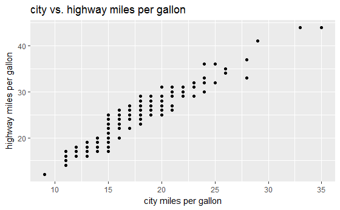

geom: including:point, bar, boxplot, line

scaling: 基本上是把我们的数据转化为电脑可识别的数据 比如将坐标映射到[0, 1]的一个数 将颜色映射到三维颜色空间中的一个点 将形状映射为一个整数

一个图包括三个部分: 1) data: 也就是geom 2) scales and coordinate system: 包括坐标轴和图例 3) plot annotations: 背景和标题

Scaling分为三个部分: transforming, training, mapping

Layers: Scales: Coordinate system: Faceting:

数据结构: 每个图包括以下几个部分 data, mapping, layers, scales, coordinates, facet, options

## Day 1 Reference book

内容是基于这本书[ggplot2: Elegant Graphics for Data Analysis](http://www.amazon.com/dp/0387981403)

另外据说这本也是个不错的参考[R Graphics Cookbook](http://www.amazon.com/dp/1449316956)

下面是ggplot2的一些文档和github上的源代码 http://docs.ggplot2.org/current/ https://github.com/hadley/ggplot2

本篇文章涉及ggplot2: Elegant Graphics for Data Analysis 中的第二章 在正式开始学习ggplot2命令之前 我们首先讨论qplot qplot是quick plot的缩写 旨在用最简短的命令画出我们所需的图

### 1. 数据

首先在R中安装ggplot2 and Import Data

```r
# Load ggplot2 package
if(!suppressWarnings(require(ggplot2)))
{
    install.packages('ggplot2')
    require(ggplot2)
}

# Read data
X <- read.delim("http://www.stat.ubc.ca/~rickw/gapminderDataFiveYear.txt")

# output as csv data
write.csv(X,file = "E:\\Github\\xiangxing98.github.io\\R_Learning\\gapminderDataFiveYear.csv", row.names = TRUE)


# Check Data X structure
str(X)
# 'data.frame': 1704 obs. of  6 variables:
#  $ country  : Factor w/ 142 levels "Afghanistan",..: 1 1 1 1 1 1 1 1 1 1 ...
#  $ year     : int  1952 1957 1962 1967 1972 1977 1982 1987 1992 1997 ...
#  $ pop      : num  8425333 9240934 10267083 11537966 13079460 ...
#  $ continent: Factor w/ 5 levels "Africa","Americas",..: 3 3 3 3 3 3 3 3 3 3 ...
#  $ lifeExp  : num  28.8 30.3 32 34 36.1 ...
#  $ gdpPercap: num  779 821 853 836 740 ...
```

### 2. qplot基本用法

qplot最简单的使用方法和R base中的plot基本一样 可以用来画散点图

```r
qplot(gdpPercap, lifeExp, data=X)
```

使用 color = year 可以将该变量用不同颜色标示出来 这里year是个连续的变量 所以颜色以谱的形式标示 用 log = “x” 表示对横轴的变量进行log变换

```r
qplot(gdpPercap, lifeExp, data=X, log = "x", color = year)
```

也可以将year变成factor 此时会用离散的颜色标示

```r
qplot(gdpPercap, lifeExp, data=X, log = "x", color = factor(year))
```

使用 size = pop 用标志的大小显示该变量的大小

```r
qplot(gdpPercap, lifeExp, data=X, log = "x", color = year, size = pop)
```

还可以使用 shape = continent 用不同的标志来显示该变量

```r
qplot(gdpPercap, lifeExp, data=X, log = "x", color = year, shape = continent)
```

最后 alpha=I(0.25) 指定透明度 0为全透明 1为不透明 当数据重叠严重时比较有用

```r
qplot(gdpPercap, lifeExp, data=X, log = "x", alpha=I(0.25))
```

### 3. geom

geom是geometric object的简称 用来生成不同种类的图

#### 3.1 smooth

首先是smooth 用来描述数据的平滑趋势 注意此处 c(“point”, “smooth”) 表示先画point 再画smooth

```r
#smooth line at top
qplot(gdpPercap, lifeExp, data=X, log = "x", alpha=I(0.5), geom=c("point", "smooth"))
```

相反的 c(“smooth”, “point”) 就是先画smooth 再画point

```r
#point at top
qplot(gdpPercap, lifeExp, data=X, log = "x", alpha=I(0.5), geom=c("smooth", "point"))
```

除了默认的平滑方法之外 还可以自行指定 比如线性模型

```r
qplot(gdpPercap, lifeExp, data=X, log = "x", alpha=I(0.5), geom=c("point", "smooth"), method=lm)
```

另外还可以自行指定公式 例如多项式回归

```r
qplot(gdpPercap, lifeExp, data=X, log = "x", alpha=I(0.5), geom=c("point", "smooth"), method=lm, formula = y ~ poly(x, 3))
```

#### 3.2 line和path

line会将数据沿横轴方向按顺序连接起来 一般用来表示时间序列数据

```r
qplot(pop, lifeExp, data=X, log = "x", alpha=I(0.5), color=year, geom="line")
```

path会将原始数据中相邻的两个点连接起来 一般用来表示二维数据随时间的变化

```r
qplot(gdpPercap, lifeExp, data=X, log = "x", alpha=I(0.5), color=year, geom=c("point", "path"))
```

#### 3.3 boxplot和jitter

和R base中的boxplot一样 横轴的数据需要是factor 注意 color=I(“red”) 中的I()是必须的 否则“red”会被当做一个新的factor

```r
X$year.fac <- factor(X$year)
qplot(year.fac, lifeExp, data=X, color=I("red"), geom="boxplot")
```

jitter和boxplot类似

```r
qplot(year.fac, lifeExp, data=X, color=I("red"), geom="jitter")
```

#### 3.4 histogram和density

这里使用 fill=continent 将直方图按不同的continent分割开

```r
qplot(lifeExp,data=X, geom="histogram", fill=continent)
```

density与histogram类似

```r
qplot(lifeExp,data=X, alpha=I(0.5), geom="density", color=continent)
```

### 4. facets

使用facets可以将一个图根据一个或两个变量的值分别显示出来 有利于更直观地进行比较 ~左边表示每一行的变量 右边表示每一列的变量 比如 continent~. 根据continent值的不同 将density的图在每一行里显示出来

```r
qplot(lifeExp,data=X, geom="density", facets=continent~.)

qplot(gdpPercap,data=X, geom="density", facets=continent~.)
```

类似的 facets=year~continent 根据每一行year和每一列continent值的不同 将histogram的图显示出来

```r
qplot(lifeExp,data=X, geom="histogram", facets=year~continent)
```

## R Graphics Cookbook

rggvis package ggplot2 package plotly package

```r
library(gcookbook)
simpledat
```